# Day 1 - Intro and GitHub

Lucas A. Nell and Maggie L. Warren

2023-11-13

## Introduction

- Go over syllabus
- Icebreaker

## Prior to class

- Install git
- Get GitHub account
- Sign up for GitHub Education Pack (https://education.github.com/pack)
- Install GitKraken

**Any issues?**

## Why use version control?

- Collaborating with a team
- Sharing code with strangers
- Tracing and avoiding horrible mistakes

**We’ll be using it throughout the class**

## Overview of git and GitHub

[figure not shown]

## Forking and cloning

[figure not shown]

## Branching, merging, and GitHub Flow

[figure not shown]

## What to include on git and GitHubList from https://doi.org/10.7287/peerj.preprints.3159v2

### Definitely include:

- Scripts (e.g., `*.R`, `*.py`)
- Raw data (especially as plain text)
- Configuration files (e.g., `*.Rproj`, `.gitignore`)

### Don’t include:

- Files that only serve a temporary purpose

### Maybe:

- Intermediate data (e.g., `*.csv`, `*.rds`)
- Figures (e.g., `*.pdf`, `*.png`)
- Reports (e.g., `*.html`, *.pdf`)

Avoid files by listing them in `.gitignore` (by full file name or by extension (e.g., *.pdf)

### Questions to ask:

#### 1. Is it useful?

#### 2. Will it cause problems with git or GitHub?

Generally avoid binary files (including `*.docx`, `*xlsx`, and `*.pdf`), especially those that are large and change a lot!

## Let’s try forking and cloning

### Fork `empty` repo:

- Go to `https://github.com/lucasnell/empty`
- Fork
- Change repo name to something descriptive about your project
- Add short description

### Clone your newly forked repo:

- Open GitKraken, click `File` > `Clone Repo`
- In URL field, type `https://github.com/<user>/<repo>.git`
- `Clone the repo!`

Alternatively, from the command line:

```bash
cd PARENT-DIRECTORY
git clone https://github.com/YOUR-USERNAME/YOUR-REPOSITORY.git
```

## Using markdown to create documentation

````
# Title of Repository

by Lucas A. Nell

## Heading 1

### Heading 2

```r
x <- runif(10)
```

```python
import random as rnd
x = [rnd.random() for i in range(10)]
```
````

### This renders as:

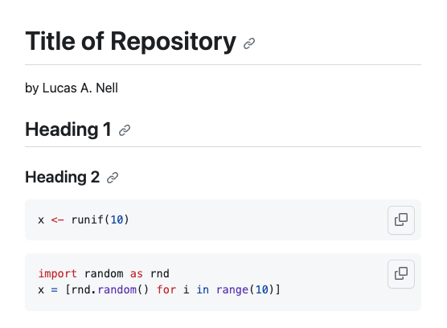

## Let’s create a `README.md` file

````
# Heading
## Sub-heading
...

1. Numbered list
2. ...

* bulleted list
  * indented item
* ...

**bold text**
*italic text*
`inline code`

```language
code chunk
```

> block quotes

![images](/path/to/images/image.png)
[links](https://google.com)
<https://google.com>
````

### Details to include:

- Project title
- Author(s)
- Project description
- How to use and install

### More markdown syntax:

https://www.markdownguide.org/basic-syntax/

## Let’s try committing and pushing

### Make changes, commit, and push:

- Edit `README.md` to properly describe your project
- In GitKraken, stage changes
- Add commit message and commit them locally
- Push changes to GitHub

Alternatively:

```bash
cd DIRECTORY
git add README.md
git commit -m "Added README.md..."
git push
```

### Verify changes at `https://github.com/<user>/<repo>`

## Providing feedback on `README.md` files

- Exchange your GitHub usernames and project repo names with someone else
- You’ll each provide feedback on the other’s `README.md` file
- Go to their repo on GitHub, look over their `README.md` and write down questions and constructive feedback
- On GitHub, click “Issues”, then “New issue”
- Put in your feedback with a title

## Conclusion

Let’s take some time to hash out your project ideas

More info on git and GitHub:

[figure not shown]

https://happygitwithr.com/